# Análisis de la Esperanza de Vida en Diferentes Regiones del Mundo

#### Prevalencia De La Subnutrición

La prevalencia de la desnutrición es un aspecto crítico para evaluar la salud y el bienestar de una población. En la base de datos original, esta variable tiene una media de 8.672414, una mediana de 6.2 y una desviación estándar de 9.422322. Tras la limpieza de la base de datos, la media disminuye significativamente a 5.677011, mientras que la mediana se mantiene en 6.2 y la desviación estándar disminuye a 3.100949. Esto indica que, en promedio, la prevalencia de la desnutrición es cercana al 5.68%, con una tendencia hacia el 6.2%. La disminución de la desviación estándar sugiere una reducción en la variabilidad de los datos tras la limpieza de la base de datos. En el contexto de este estudio, se puede concluir que la desnutrición sigue siendo un desafío, pero la limpieza de los datos ha reducido la variabilidad en los valores registrados.

##### Base de datos original:

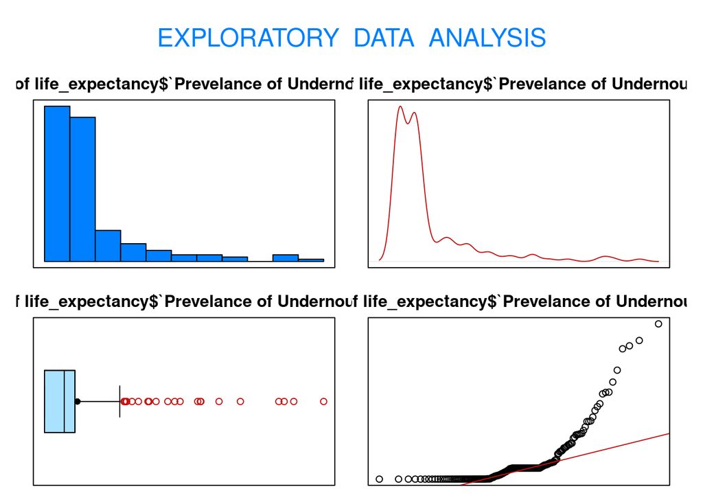

```
## Size (n)  Missing  Minimum   1st Qu     Mean   Median   TrMean   3rd Qu
##  174.000    0.000    2.500    2.500    8.672    6.200    7.299    8.175
##      Max    Stdev      Var  SE Mean   I.Q.R.    Range Kurtosis Skewness
##   54.800    9.422   88.780    0.714    5.675   52.300    7.441    2.621
## SW p-val
##    0.000
```

```r
eda(life_expectancy$`Prevelance of Undernourishment`)
```

##### Base de datos limpia:

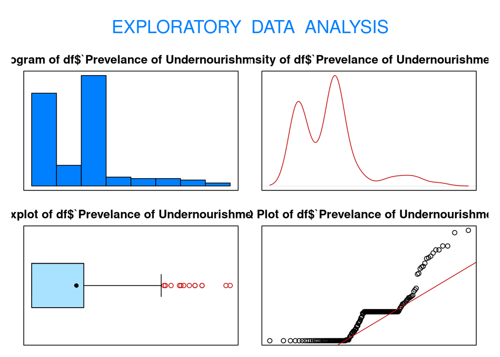

```
## Size (n)  Missing  Minimum   1st Qu     Mean   Median   TrMean   3rd Qu
##  174.000    0.000    2.500    2.500    5.677    6.200    5.383    6.200
##      Max    Stdev      Var  SE Mean   I.Q.R.    Range Kurtosis Skewness
##   16.600    3.101    9.616    0.235    3.700   14.100    1.805    1.291
## SW p-val
##    0.000
```

```r
eda(df$`Prevelance of Undernourishment`)
```